# Estudo do Estilo Arquitetural Cliente-Servidor: Sala de Conversas

LP4A/PUCSP, ItaloSV, 2018

# 1 Experimento Sala de Conversas

Vamos projetar uma aplicação cliente-servidor capaz de difundir mensagens entre os participantes em uma sala de conversas.

O projeto desta aplicação foi inspirado no material https://docs.oracle.com/javase/tutorial/networking/sockets/index.html.

# 2 Aplicação-Cliente

A aplicação deve se registrar na aplicação-servidor, sendo atendida na porta 9001. A comunicação com o servidor fará uso da tecnologia de *sockets*, oferecida nativamente em Java.

Serão utilizadas três classes:

- `Main`, contendo a lógica que irá criar um novo fluxo de eventos, agora em Swing,
- `Cliente`, que implementará a lógica da interface com o participante e
- `Tarefa`, contendo a lógica de comandos em termos do protocolo de comunicação da sala de conversas.

## 2.1 Classe `Main`

A classe `Main` refina o componente aplicação-cliente da sala de conversas (fig. 1). Ela contém os detalhes da arquitetura de execução `Cliente`. Em particular, a comunicação com a aplicação-servidor será feita por meio de *sockets* usando os protocolos TCP/IP.

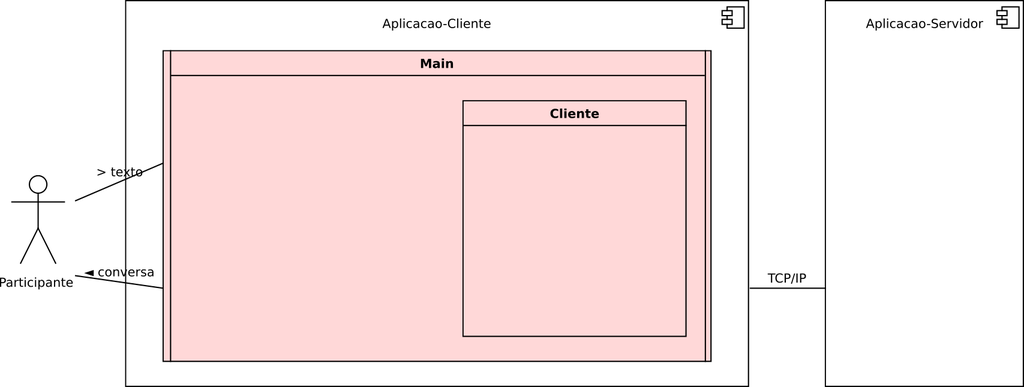

Figura 1: Arquitetura da aplicação-cliente

O fluxo principal da aplicação-cliente, encapsulado na classe `Cliente`, é mostrado na lst. 1.

Listagem 1: Classe Main

```java
// cs5::chat::cliente::Main::
public class Main {

    public static void main(String[] args) throws Exception {
        Cliente cliente = new Cliente();
        cliente.run();
    }
}
```

## 2.2 Classe `Cliente`

**Interface exigida** A aplicação-cliente interagirá com o participante da sala de conversas por meio de elementos da tecnologia Swing, nesta versão. Além disso, será necessária a interface `Socket` para que seja estabelecida uma linha de comunicação com a aplicação-servidor, como sugerido no diagrama mostrado na fig. 2. Os detalhes deste desenho na linguagem Java encontram-se na lst. 2.

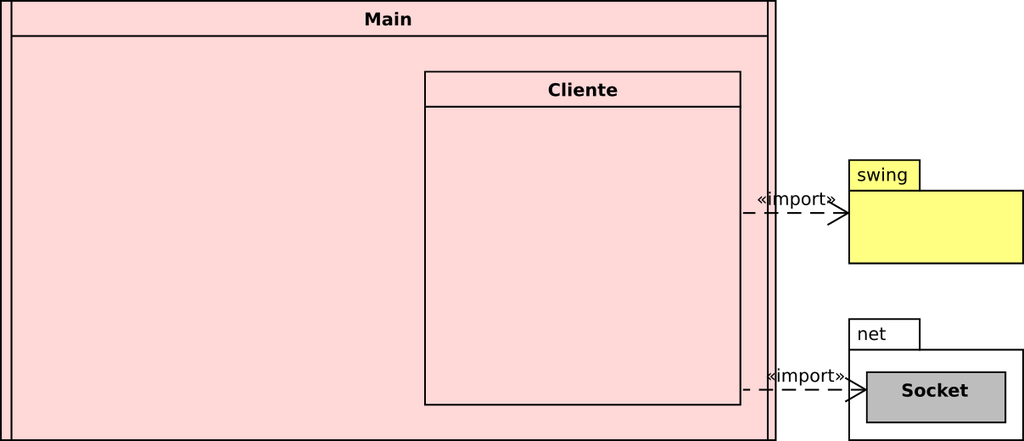

Figura 2: Interface exigida pela classe Cliente

Listagem 2: Interface exigida

```java
// cs5::chat::cliente::Cliente::
import java.io.IOException;
import java.io.PrintWriter;
import java.net.Socket;
import javax.swing.JFrame;
import javax.swing.JOptionPane;
import javax.swing.JScrollPane;
import javax.swing.JTextArea;
import javax.swing.JTextField;
// class Cliente { // <--
```

**Método construtor** O método de construção de objetos da classe `Cliente` deve descrever o painel de interação com o participante da sala. Dois elementos são centrais no painel (fig. 3):

- um campo de texto, utilizado para digitar mensagens para os demais participantes, e
- uma área de conversas, que mostrará as mensagens de todos os participantes da sala de conversas.

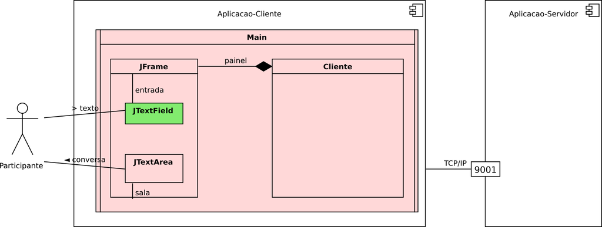

Figura 3: Detalhes da interface com o usuário

Inicialmente, iremos desativar estes elementos de interação com respeito à edição. Somente após a entrada na sala é que o campo de texto passará ao estado editável.

Listagem 3: Método construtor

```java
    // cs5::chat::cliente::Cliente::
    Cliente() {
        // Elementos de interação
        entrada = new JTextField(40);
        sala = new JTextArea(8, 40);
        // Propriedades de edição
        entrada.setEditable(false);
        sala.setEditable(false);
        // Organização da interface e palco principal
        painel = new JFrame("Conversa (v0.1)");
        painel.getContentPane().add(entrada, "North");
        painel.getContentPane().add(new JScrollPane(sala), "Center");
        painel.pack();
        painel.setDefaultCloseOperation(JFrame.EXIT_ON_CLOSE);
        painel.setVisible(true);
    }

    JFrame painel;
    JTextField entrada;
    JTextArea sala;
    Tarefa t;
```

**Endereço do servidor** Em um primeiro momento, o endereço da máquina na qual se executa a aplicação-servidor terá o endereço fixo, estático: `"127.0.0.1"` (ou `"localhost"`), como mostrado na lst. 4. Posteriormente, o trecho comentado poderá ser liberado, de modo que este endereço seja fornecido dinamicamente.

Listagem 4: Obtenção do endereço do servidor

```java
    // cs5::chat::cliente::Cliente::
    String obterIpServidor() {
        // return JOptionPane.showInputDialog(
        // painel,
        // "Endereço IP do servidor:",
        // "Recepção da Sala de Conversas",
        // JOptionPane.QUESTION_MESSAGE);
        return "127.0.0.1";
    }
```

**Tratamento de eventos ‘publicar texto’** As decisões centrais de modelagem referentes ao envio de mensagens de texto para a sala encontram-se no diagrama mostrado na fig. 4.

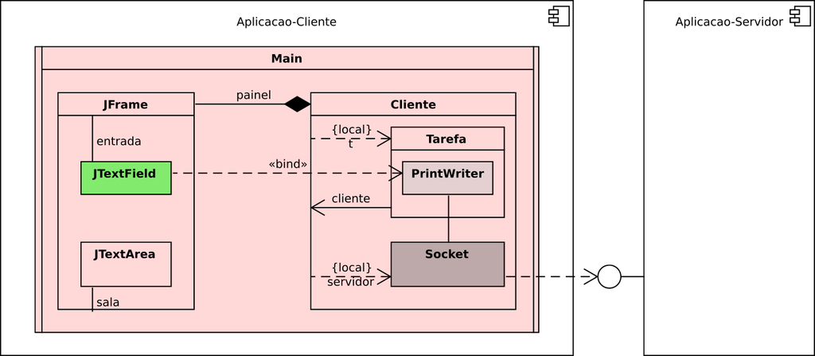

Figura 4: Detalhes da classe Cliente

A entrada de texto, implementada com um objeto da classe `JTextField`, deverá passar para o estado editável, de modo que, a cada *enter* do participante, o texto digitado seja enviado pelo fluxo de saída da tarefa. Assim que transmitido, limpa-se o campo de entrada (lst. 5).

Listagem 5: Tratamento de eventos 'publicar texto'

```java
    // cs5::chat::cliente::Cliente::
    void liberarConversa() {
        entrada.setEditable(true);
    }

    void tratarDigitacao(JTextField entrada, PrintWriter fluxoSaida) {
        entrada.addActionListener((e) -> {
            String texto = entrada.getText();
            fluxoSaida.println(texto); // <-- (1)
            entrada.setText("");
        });
    }

    void mostrar(String texto) {
        sala.append(texto.substring(9) + "\n");
    }
```

Uma observação no método `mostrar()`. Este método será executado sempre que o servidor difundir um comando `MENSAGEM`, que possui a seguinte estrutura:

```
MENSAGEM <nome>: <texto>
|||||||||
123456789
```

O resultado da chamada `texto.substring(9)` corresponde ao valor `String` formado pelo nome e pelo texto digitado pelo participante; ou seja:

```
<nome>: <texto>
```

É este resultado que será adicionado à área de texto `sala`. Logo, se a tarefa do servidor fizer alguma alteração na montagem da estrutura do comando `MENSAGEM`, este método da classe `Cliente` será diretamente afetado.

**Nomes dos participantes** Para entrar na sala, cada participante deverá informar o seu nome (lst. 6). Durante a realização da tarefa, o comando de `REGISTRO` será enviado pelo servidor, que ficará aguardando (`readLine()`) o `String` representando o nome do participante, transmitido pela aplicação-cliente.

Listagem 6: Nomes dos participantes

```java
    // cs5::chat::cliente::Cliente::
    String obterParticipante() {
        String nome = JOptionPane.showInputDialog(painel,
            "Qual o seu nome?",
            "Escolha de Nome",
            JOptionPane.PLAIN_MESSAGE);
        String titulo = painel.getTitle();
        painel.setTitle(titulo + ": " + nome);
        return nome;
    }
```

**Lógica da aplicação-cliente** Finalmente, chegamos aos detalhes da lógica principal do cliente. Após obter o endereço IP da máquina na qual se encontra em execução a aplicação-servidor, tenta-se abrir a porta de comunicação (lst. 7). Recebendo a confirmação do servidor, executa-se a tarefa do cliente.

Listagem 7: Método do fluxo do cliente

```java
    // cs5::chat::cliente::Cliente::
    void run() throws IOException {
        String ipServidor = obterIpServidor();
        int PORTA = 9001;
        Socket servidor = new Socket(ipServidor, PORTA);
        t = new Tarefa(servidor);
        t.associar(this);
        tratarDigitacao(entrada, t.fluxoSaida);
        t.run();
    }
```

## 2.3 Classe `Tarefa`

**Interface exigida** A interface da classe `Tarefa` estabelece dependências em relação aos fluxos de entrada e de saída, bem como ao mecanismo de `Socket` da tecnologia Java (lst. 8).

Listagem 8: Interface exigida

```java
// cs5::chat::cliente::Tarefa::
import java.io.BufferedOutputStream;
import java.io.BufferedReader;
import java.io.IOException;
import java.io.InputStream;
import java.io.InputStreamReader;
import java.io.OutputStream;
import java.io.PrintWriter;
import java.net.Socket;
// public class Tarefa { // <--
```

**Construtor de tarefas** O construtor de uma particular tarefa associa um fluxo de entrada e outro de saída (de valores do tipo `String`) aos respectivos pontos de acesso do `Socket` que representa o servidor na aplicação-cliente (lst. 9).

Listagem 9: Método construtor

```java
    // cs5::chat::cliente::Tarefa::
    Tarefa(Socket servidor) throws IOException {
        fluxoEntrada = definirFluxoEntrada(servidor);
        fluxoSaida = definirFluxoSaida(servidor);
    }

    BufferedReader fluxoEntrada;
    PrintWriter fluxoSaida;
```

**Fluxos de entrada e de saída** Os fluxos de entrada e de saída são definidos por meio de decorações realizadas sobre os fluxos mais primitivos, oferecidos pela classe `Socket` (lst. 10 e lst. 11).

Listagem 10: Fluxo de entrada

```java
    // cs5::chat::cliente::Tarefa::
    public BufferedReader definirFluxoEntrada(Socket servidor) throws IOException {
        InputStream is = servidor.getInputStream();
        InputStreamReader istream = new InputStreamReader(is);
        return new BufferedReader(istream);
    }
```

Listagem 11: Fluxo de saída

```java
    // cs5::chat::cliente::Tarefa::
    public PrintWriter definirFluxoSaida(Socket servidor) throws IOException {
        OutputStream os = servidor.getOutputStream();
        BufferedOutputStream ostream = new BufferedOutputStream(os);
        // flush por write
        return new PrintWriter(ostream, true);
    }
```

Um elemento estrutural importante é aquele que permite á tarefa, comunicar-se com o objeto `Cliente` que a contém (lst. 12). Esta comunicação centraliza a realização da tarefa da aplicação-cliente, detalhada na próxima sessão.

Listagem 12: Associação da tarefa

```java
    // cs5::chat::cliente::Tarefa::
    void associar(Cliente c) {
        cliente = c;
    }

    Cliente cliente;
```

**Lógica da tarefa** A lógica central da tarefa da aplicação-cliente encontra-se na classe `Tarefa` (fig. 5). O método `run()` implementa o interpretador de comandos enviados e recebidos na comunicação com o servidor.

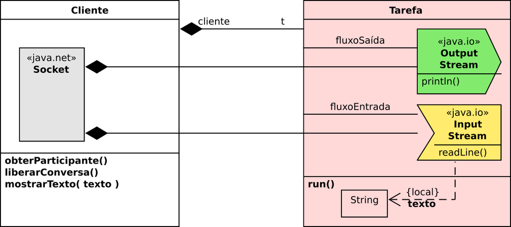

Figura 5: Lógica de interpretação da tarefa

Listagem 13: Lógica da tarefa

```java
    // cs5::chat::cliente::Tarefa::
    void run() throws IOException {
        while (true) {
            String texto = fluxoEntrada.readLine();
            if (texto.startsWith("REGISTRO")) {
                String nome = cliente.obterParticipante();
                fluxoSaida.println(nome);
            } else if (texto.startsWith("ACEITO")) {
                cliente.liberarConversa();
            } else if (texto.startsWith("MENSAGEM")) {
                cliente.mostrar(texto);
            }
        }
    }
```

# 3 Aplicação-Servidor

A aplicação-servidor conterá duas classes ativas de objetos:

- `Main` e
- `Executor`.

A primeira será responsável por aceitar conexões das aplicações-cliente (fig. 6).

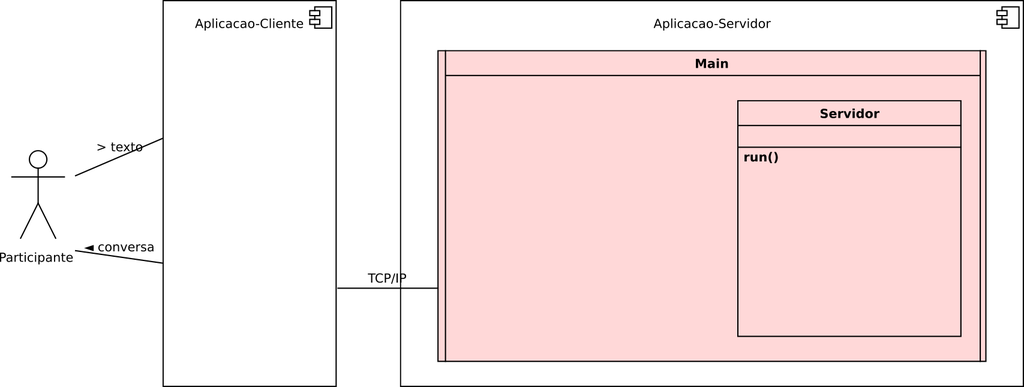

Figura 6: Arquitetura da aplicação-servidor

## 3.1 Classe `Main`

A classe `Main` instancia um `Servidor s`, responsável pela estrutura de execução da aplicação-servidor (lst. 14).

Listagem 14: Fluxo principal do servidor

```java
// cs5::chat::servidor::Main::
public class Main {

    public static void main(String[] args) throws Exception {
        System.out.println("O servidor da sala de conversas está rodando...");
        Servidor s = new Servidor();
        s.run();
    }
}
```

## 3.2 Classe `Servidor`

A interface exigida pela classe `Servidor` estabelece dependências em relação ao suporte de coleções `util` de objetos, aos fluxos de entrada e de saída, `io` e, principalmente, em relação ao mecanismo Java de implementação de *sockets* (fig. 7).

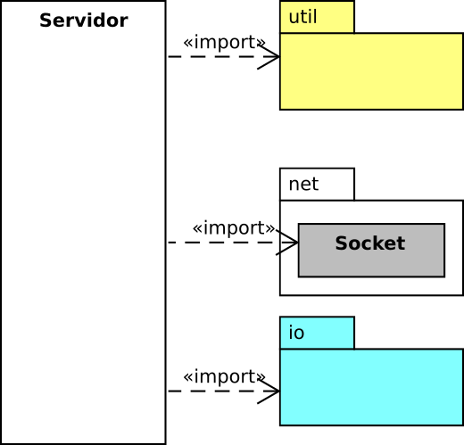

Figura 7: Interface exigida pela classe Servidor

A codificação desta interface pode ser vista na lst. 15.

Listagem 15: Interface exigida

```java
// cs5::chat::servidor::Servidor::
import java.io.IOException;
import java.io.PrintWriter;
import java.net.ServerSocket;
import java.net.Socket;
import java.util.HashMap;
import java.util.Map;
// public class Servidor { // <--
```

**Construtor** A principal estrutura do servidor refere-se ao mapa (dicionário) de fluxos de saída, indexados pelo nome do participante (fig. 8). A estrutura é instanciada durante a execução do método construtor (lst. 16).

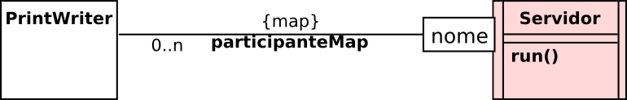

Figura 8: Participantes e fluxos de saída do servidor

Listagem 16: Método construtor

```java
    // cs5::chat::servidor::Servidor::
    Servidor() {
        participanteMap = new HashMap<>();
    }

    Map<String, PrintWriter> participanteMap;
```

O dicionário `participanteMap` da sala de conversas será mantido por meio das seguintes operações:

- recepção de participante,
- publicação de mensagens de texto e
- remoção de participante.

A recepção de participante (lst. 17) recebe um par constituído pelo nome (do participante) e por um fluxo de saída (do *socket* utilizado para a comunicação com a aplicação-cliente). Caso o nome deste participante ainda não pertença ao dicionário, ele será inserido e um alerta será emitido no terminal do servidor.

Listagem 17: Recepção de participantes

```java
    // cs5::chat::servidor::Servidor::
    boolean receber(String nome, PrintWriter fs) {
        // Condição de corrida?
        if (!participanteMap.containsKey(nome)) {
            participanteMap.put(nome, fs);
            System.out.println(nome + " entrou na sala.");
            return true;
        }
        return false;
    }
```

Por outro lado, sempre que um participante enviar uma mensagem de texto, o método `difundir()` será executado (lst. 18). A difusão de uma mensagem envolve três dados: o comando de envio de mensagem, o nome do participante e a mensagem por ele digitada. Neste caso, o servidor percorre o dicionário e, para cada participante `p`, ele envia o `dado` para o respectivo fluxo de saída `fs`.

Listagem 18: Publicação de mensagens

```java
    // cs5::chat::servidor::Servidor::
    void difundir(String cmd, String nome, String texto) {
        participanteMap.forEach((p, fs) -> {
            String dado = cmd + " " + nome + ": " + texto;
            fs.println(dado);
        });
    }
```

Finalmente, quando um participante encerra a sua aplicação-cliente, a conexão com o servidor (via *socket*) se desfaz. Como consequência, o servidor remove este participante do seu dicionário (lst. 19).

Listagem 19: Remoção de participantes

```java
    // cs5::chat::servidor::Servidor::
    void remover(String nome) {
        if (nome != null) {
            participanteMap.remove(nome);
            System.out.println(nome + " saiu da sala.");
        }
    }
```

**Fluxo do servidor**

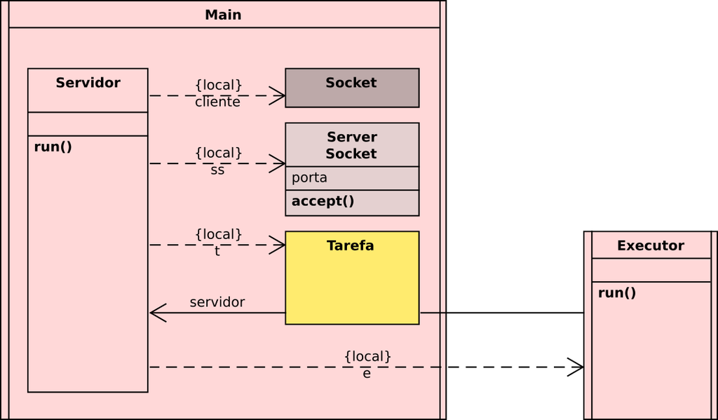

Figura 9: Detalhes da estrutura do servidor

O fluxo de controle do servidor segue o padrão dos ensaios anteriores (lst. 20):

1. instanciamos um servidor de *sockets*;
2. aguardamos uma conexão de cliente;
3. instanciamos a lógica da tarefa para atender ao cliente;
4. atendemos o cliente em um fluxo de controle separado.

Listagem 20: Lógica do servidor

```java
    // cs5::chat::servidor::Servidor::
    void run() throws IOException {
        int PORT = 9001;
        try (ServerSocket ss = new ServerSocket(PORT)) { // (1)
            while (true) {
                Socket cliente = ss.accept();   // (2)
                Tarefa t = new Tarefa(this, cliente); // (3)
                Executor e = new Executor(t);   // (4)
                e.start();
            }
        }
    }
```

## 3.3 Classe `Executor`

Listagem 21: Executor da tarefa do servidor

```java
// cs5::chat::servidor::Executor::
class Executor extends Thread {

    Executor(Tarefa t) {
        super();
        tarefa = t;
    }

    Tarefa tarefa;

    @Override
    public void run() {
        tarefa.run(); // <--(1)
    }
}
```

## 3.4 Classe `Tarefa`

**Interface exigida** A interface da tarefa do servidor revela sua dependência em relação ao mecanismo de *sockets* e entrada e saída da tecnologia Java (fig. 10 e lst. 22).

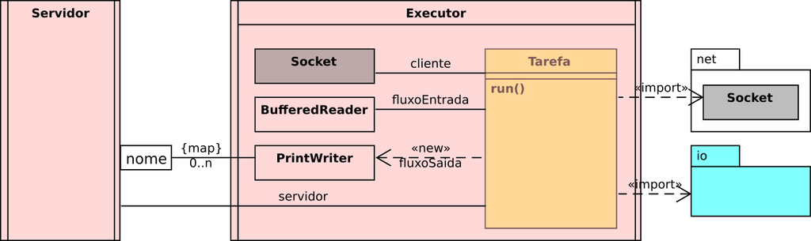

Figura 10: Detalhes da estrutura da tarefa do servidor

Listagem 22: Interface exigida

```java
// cs5::chat::servidor::Tarefa::
import java.io.BufferedReader;
import java.io.IOException;
import java.io.InputStreamReader;
import java.io.PrintWriter;
import java.net.Socket;
// class Tarefa { // <--
```

**Construtor** O método construtor instancia a estrutura da tarefa (lst. 23): o objeto que mantém a estrutura de dados do servidor e o *socket* que representa a aplicação-cliente.

Listagem 23: Método construtor

```java
    // cs5::chat::servidor::Tarefa::
    Tarefa(Servidor s, Socket c) {
        servidor = s;
        cliente = c;
    }
    Servidor servidor;
    Socket cliente;
```

**Fluxo da tarefa do servidor** O fluxo de controle da tarefa do servidor apresenta quatro etapas (lst. 24):

1. registro de um participante,
2. difusão de mensagens do participante,
3. remoção do participante da sala e
4. fechamendo da conexão com a aplicação-cliente.

Listagem 24: Fluxo da tarefa do servidor

```java
    // cs5::chat::servidor::Tarefa::
    void run() {
        try {
            if (registrarParticipante()) {      // (1)
                // ciclo perpétuo...
                difundir();                     // (2)
                servidor.remover(participante); // (3)
            }
        } catch (IOException e) {
        } finally {
            try {
                cliente.close();                // (4)
            } catch (IOException e) {
            }
        }
    }
```

**Registro do participante** O registro do participante utiliza uma janela de diálogo para que ele informe o seu nome (lst. 25). Fica-se em um ciclo perpétuo até que o nome digitado não esteja no dicionário de participantes do servidor, ou até que o participante feche, simplesmente, a janela de diálogo.

Listagem 25: Solicitação do nome do participante

```java
    // cs5::chat::servidor::Tarefa::
    boolean registrarParticipante() throws IOException {
        fluxoEntrada = new BufferedReader(new InputStreamReader(cliente.getInputStream()));
        PrintWriter fluxoSaida = new PrintWriter(cliente.getOutputStream(), true);
        while (true) {
            String cmd = "REGISTRO";
            fluxoSaida.println(cmd);
            participante = fluxoEntrada.readLine();
            if (participante == null) {
                return false;
            }
            if (servidor.receber(participante, fluxoSaida)) {
                cmd = "ACEITO";
                fluxoSaida.println(cmd);
                break;
            }
        }
        return true;
    }
    String participante;
    BufferedReader fluxoEntrada;
```

Sob o ponto de vista da comunicação entre processos, o protocolo de registro envolve dois comandos:

- `"REGISTRO"`, enviado pelo servidor para o cliente, informando que está no aguardo de um `String` que representa o nome do participante;
- `"ACEITO"`, enviado pelo servidor, informando à aplicação-cliente que pode deixar o participante digitar mensagens de texto.

**Difusão das mensagens do participante** Depois que o participante foi registrado na sala de conversas, as suas mensagens são difundidas pela tarefa do servidor, que entra em um ciclo perpétuo de difusão.

```java
    // cs5::chat::servidor::Tarefa::
    void difundir() throws IOException {
        while (true) {
            String texto = fluxoEntrada.readLine();
            if (texto == null) {
                return;
            }
            String cmd = "MENSAGEM";
            servidor.difundir(cmd, participante, texto);
        }
    }
```

A tarefa encerra o ciclo de difusão quanto o participante fecha a aplicação-cliente. Neste caso, `readLine()` retorna o valor `null`, de acordo com a documentação da tecnologia (https://docs.oracle.com/javase/8/docs/api/java/io/BufferedReader.html).

# 4 Considerações

1. Execute a aplicação-servidor e, em seguida, a aplicação-cliente localmente. O que acontece quando você envia mensagens para a sala de conversas?
2. A lógica da aplicação-cliente de modo que o endereço do servidor possa ser obtido dinamicamente. Execute esta aplicação em uma máquina diferente daquela na qual o servidor está rodando.
3. Altere a tarefa da aplicação-servidor de modo que o registro de cada participante seja informado na sala de conversas.
4. Desenvolva uma aplicação-cliente usando a tecnologia JavaFX.